# Usando R&Python

[output not shown]

```
###### Bruno Lima Q. S.
```

```
27/05/2020
```

###### Bruno Lima Q. S.

27/05/2020

[output not shown]

```
Em um contexto em que há alguma polarização sobre o uso de `R` e `Python`, pode ser interessante saber que é possível utilizar ambos em um mesmo projeto, inclusive em um mesmo programa. Isso posibilita o aproveitamento dos melhores recursos de ambas linguagems em um mesmo projeto e amplia as possibilidades de trabalho.
```

Em um contexto em que há alguma polarização sobre o uso de `R` e `Python`, pode ser interessante saber que é possível utilizar ambos em um mesmo projeto, inclusive em um mesmo programa. Isso posibilita o aproveitamento dos melhores recursos de ambas linguagems em um mesmo projeto e amplia as possibilidades de trabalho.

[output not shown]

```
Exemplificarei isso apresentando algumas estratégias por meio do recurso `rpy2` *baixo nível*, que permite mais eficiência e personalização na utilização do recurso. [1](https://rpy2.github.io/doc/v2.9.x/html/rinterface.html)
```

Exemplificarei isso apresentando algumas estratégias por meio do recurso `rpy2` *baixo nível*, que permite mais eficiência e personalização na utilização do recurso. [1](https://rpy2.github.io/doc/v2.9.x/html/rinterface.html)

[output not shown]

```
O princípio geral da estratégia de utilização desse recurso é anotar o código destinado a ser interpretado pelo `R` na forma de *string* e utilizá-lo em um mecanismo de execução a partir de *string* fornecida.
```

```
Detalhes do funcionamento do pacote podem ser obtidos na sua documentação.
```

O princípio geral da estratégia de utilização desse recurso é anotar o código destinado a ser interpretado pelo `R` na forma de *string* e utilizá-lo em um mecanismo de execução a partir de *string* fornecida.

Detalhes do funcionamento do pacote podem ser obtidos na sua documentação.

[output not shown]

```
# Introdução
```

# Introdução

[output not shown]

```
_
```

```
Criam-se processos `R` e `Python` com tempo de execução não simultâneos entre si. Esse modelo é satisfatório para um bom aproveitamento.
```

```
Assim, quando um programa de código `R` tiver sua execução concluída, sua sessão iterativa será pausada para que o processo iterativo `Python` continue.
```

_

Criam-se processos `R` e `Python` com tempo de execução não simultâneos entre si. Esse modelo é satisfatório para um bom aproveitamento.

Assim, quando um programa de código `R` tiver sua execução concluída, sua sessão iterativa será pausada para que o processo iterativo `Python` continue.

[output not shown]

```
O destino padrão do **output textual** das funções `print` e `cat` no `R` será o terminal. Pode-se programar o desvio para o `jupyter-notebook` ou outra interface interativa. Isso pode ser feito desviando-se o resultado para um arquivo *.txt* temporário e finalmente para a interface interativa.
```

```
Uma estratégia análoga pode ser utilizada para o desvio de resultados em **imagens**, que são, por padrão, abertas em dispositivos interativos (janelas).
```

```
Analogamente, pode-se utilizar arquivos *txt* temporários como intermediários de **interconversão de variáveis** por meio do formato *data frame*. A ideia é hospedar uma variável de um processo em um arquivo temporário *txt*. Pode ser interessante armazenar a variável nesse arquivo pelo formato *data frame*, que seria um formato intermediário entre os processos.
```

```
Ou seja, a comunicação de resultados dos processos pode ocorrer por meio de arquivos temporários e mecanismos de importação e exportação.
```

```
Essas estratégias podem ser automatizadas pelo usuário, sobretudo conhecendo-se as técnicas a seguir.
```

O destino padrão do **output textual** das funções `print` e `cat` no `R` será o terminal. Pode-se programar o desvio para o `jupyter-notebook` ou outra interface interativa. Isso pode ser feito desviando-se o resultado para um arquivo *.txt* temporário e finalmente para a interface interativa.

Uma estratégia análoga pode ser utilizada para o desvio de resultados em **imagens**, que são, por padrão, abertas em dispositivos interativos (janelas).

Analogamente, pode-se utilizar arquivos *txt* temporários como intermediários de **interconversão de variáveis** por meio do formato *data frame*. A ideia é hospedar uma variável de um processo em um arquivo temporário *txt*. Pode ser interessante armazenar a variável nesse arquivo pelo formato *data frame*, que seria um formato intermediário entre os processos.

Ou seja, a comunicação de resultados dos processos pode ocorrer por meio de arquivos temporários e mecanismos de importação e exportação.

Essas estratégias podem ser automatizadas pelo usuário, sobretudo conhecendo-se as técnicas a seguir.

[output not shown]

```
# Primeira estratégia
```

# Primeira estratégia

```
import rpy2.rinterface as ri
```

```
ri.initr()
```

```
# A configuração demarcada abaixo é diferente.
```

```
# Recomendo cuidado com essa configuração
```

```
# Algumas inconsistências podem surgir com respeito ao funcionamento do `R`.
```

```
# ------------ V ----------------#
```

```
rr=ri.parse
```

```
rR=ri.baseenv["eval"]
```

```
# ------------ ^ ----------------#
```

```
k=rr("""
```

```
hist(c(1:10))
```

```
while(
```

```
    !is.null(
```

```
        dev.list()
```

```
    )
```

```
){} # não faça nada
```

```
""")
```

```
k=rR(k)
```

[output not shown]

```
Num console `R` não seria necessário tomar cuidado com a finalização da instrução, porque não há interrupção dela. No entanto, aqui essa interrupção ocorrerá ao final da execução. Por isso tomou-se o cuidado de manter a sessão iterativa do `R` por meio de uma execução de código em `R` até que a janela interativa (dispositivo) que hospeda a imagem seja fechada pelo usuário, evitando um *crashing*.
```

Num console `R` não seria necessário tomar cuidado com a finalização da instrução, porque não há interrupção dela. No entanto, aqui essa interrupção ocorrerá ao final da execução. Por isso tomou-se o cuidado de manter a sessão iterativa do `R` por meio de uma execução de código em `R` até que a janela interativa (dispositivo) que hospeda a imagem seja fechada pelo usuário, evitando um *crashing*.

[output not shown]

```
Um incoveniente desse modo é o destaque do código R na forma de string. Para contornar isso, pode-se lançar mão de duas outras estratégias.
```

Um incoveniente desse modo é o destaque do código R na forma de string. Para contornar isso, pode-se lançar mão de duas outras estratégias.

[output not shown]

```
# Segunda estratégia
```

# Segunda estratégia

[output not shown]

```
####  utilizando Custom magics
```

#### utilizando Custom magics

```
# Configurações
```

```
from IPython.core.magic import register_line_cell_magic
```

```
import rpy2.rinterface as ri
```

```
#import os
```

```
ri.initr()
```

```
rb=ri.baseenv
```

```
rg=ri.globalenv
```

```
rs=ri.StrSexpVector
```

```
# ----------------------- #
```

```
# ----------------- vvvvvvvvvv -----------------#
```

```
# PARA VERSÕES MAIS ATUAIS do RPY2 , 27/05/2020
```

```
# Acrescente o comando abaixo:
```

```
#rb.get=rb.find
```

```
# ----------------- ^^^^^^^^^^ -----------------#
```

```
rp=rb.get("parse")
```

```
# ---------------------- #
```

```
re=rb["eval"]
```

```
rint=ri.IntSexpVector
```

```
"""~~~~~~~~~~~~~~~~~~~~~~~~~~~~~~~~"""
```

```
rfilename=rs([""])
```

```
rn=rint(["-1"])
```

```
"""~~~~~~~~~~~~~~~~~~~~~~~~~~~~~~~~"""
```

```
def reval(text):
```

```
    #rs=ri.StrSexpVector
```

```
    text=rs([text])
```

```
    #filename=rs([""])
```

```
    #n=rint(["-1"])
```

```
    k=re(
```

```
        rp(rfilename,rn,text)
```

```
    )
```

```
    return None
```

```
### Poderiam ter sido usadas classes.
```

```
@register_line_cell_magic
```

```
def r(line, cell=None):
```

```
    "Magic that works both as %r and as %%r"
```

```
    if cell is None:
```

```
        reval(line)
```

```
        return None
```

```
        #return line
```

```
    else:
```

```
        reval(cell)
```

```
        return None
```

```
        #return line, cell
```

```
# deletando para evitar conflitos
```

```
del r
```

[output not shown]

```
Uso exemplificado abaixo
```

Uso exemplificado abaixo

```
a=0.1
```

```
%r a<-10
```

```
%r print(a)
```

```
print(a)
```

```
0.1
```

```
%%r
```

```
b<-10
```

```
print(b)
```

```
hist(c(1:10))
```

```
while(
```

```
    !is.null(
```

```
        dev.list()
```

```
    )
```

```
){} # não faça nada
```

[output not shown]

```
O inconveniente desse método pode ser a falta de elegância em usar um código destinado ao `R` e um destinado ao `Python` em uma mesma célula.
```

O inconveniente desse método pode ser a falta de elegância em usar um código destinado ao `R` e um destinado ao `Python` em uma mesma célula.

[output not shown]

```
# Terceira estratégia
```

# Terceira estratégia

[output not shown]

```
#### Custom input
```

#### Custom input

[output not shown]

```
_
```

```
Requer IPython atualizado
```

```
A atualização pode ser feita no Colab pelo comando :
```

```
`pip install ipython --upgrade`
```

_

Requer IPython atualizado

A atualização pode ser feita no Colab pelo comando :

`pip install ipython --upgrade`

```
# Configurações
```

```
from IPython.core.getipython import get_ipython
```

```
import rpy2.rinterface as ri
```

```
ri.initr()
```

```
rb=ri.baseenv
```

```
rg=ri.globalenv
```

```
rs=ri.StrSexpVector
```

```
# ----------------------- #
```

```
# ----------------- VVVVVVVVVV -----------------#
```

```
# PARA VERSÕES MAIS ATUAIS do RPY2 , 27/05/2020
```

```
# Acrescente o comando abaixo:
```

```
#rb.get=rb.find
```

```
# ----------------- ^^^^^^^^^^ -----------------#
```

```
rp=rb.get("parse")
```

```
# ---------------------- #
```

```
re=rb["eval"]
```

```
rint=ri.IntSexpVector
```

```
"""~~~~~~~~~~~~~~~~~~~~~~~~~~~~~~~~"""
```

```
rfilename=rs([""])
```

```
rn=rint(["-1"])
```

```
"""~~~~~~~~~~~~~~~~~~~~~~~~~~~~~~~~"""
```

```
def reval(text):
```

```
    #rs=ri.StrSexpVector
```

```
    text=rs([text])
```

```
    #filename=rs([""])
```

```
    #n=rint(["-1"])
```

```
    k=re(
```

```
        rp(rfilename,rn,text)
```

```
    )
```

```
    return None
```

```
# ========================================= #
```

```
# Alterando o input recebido por uma célula #
```

```
def r_input(lines):
```

```
    new_lines = []
```

```
    for line in lines:
```

```
        chars=line
```

```
    # ~~~~~~~~~~~~~~~~~~~~~~~~~#
```

```
        if(chars=="%r\n"): # Abertura do código em R / Sinalização
```

```
    # ~~~~~~~~~~~~~~~~~~~~~~~~~#
```

```
            chars='''text="""\n'''
```

```
        else:
```

```
        # ~~~~~~~~~~~~~~~~~~~~~~~~~#
```

```
            if(chars=="r%\n"): # Fechamento do código em R / Sinalização
```

```
        # ~~~~~~~~~~~~~~~~~~~~~~~~~#
```

```
                chars='''"""\n'''
```

```
                chars=chars+"reval(text)\n"
```

```
        new_lines.append(chars)
```

```
    return new_lines
```

```
ip = get_ipython()
```

```
ip.input_transformers_cleanup.append(r_input)
```

```
D=100
```

```
print(D)
```

```
%r
```

```
C<-9
```

```
print(C)
```

```
hist(c(1:10))
```

```
while(
```

```
    !is.null(
```

```
        dev.list()
```

```
    )
```

```
){} # não faça nada
```

```
r%
```

```
C=0.9
```

```
print(C)
```

```
100
0.9
```

[output not shown]

```
Considerando que todas as estratégias produzem o mesmo efeito, diferindo entre si na personalização de uso do usuário, seguirei apresentando alguns exemplos de utilização a partir da técnica de *custom input*.
```

Considerando que todas as estratégias produzem o mesmo efeito, diferindo entre si na personalização de uso do usuário, seguirei apresentando alguns exemplos de utilização a partir da técnica de *custom input*.

[output not shown]

```
# Exemplos
```

# Exemplos

[output not shown]

```
I) Output textual
```

I) Output textual

```
%r
```

```
a<-10
```

```
b<-20
```

```
A<-c(a,b)
```

```
print(A)
```

```
r%
```

[output not shown]

```
Resultado no terminal :
```

Resultado no terminal :

[output not shown]

```
![](FOTO1.png)
```

[figure not shown]

[output not shown]

```
Para exibir no Jupyter-Notebook, precisou-se recorrer a um mecanismo de desvio de output
```

Para exibir no Jupyter-Notebook, precisou-se recorrer a um mecanismo de desvio de output

```
%r
```

```
sink("temporary.txt") # MUDANDO O DESTINO DO OUTPUT
```

```
a<-10
```

```
b<-20
```

```
A<-c(a,b)
```

```
print(A)
```

```
sink() # RETORNANDO O DESTINO DO OUTPUT PARA O CONSOLE (terminal)
```

```
# file.remove("temporary.txt") ou unlink("temporary.txt")
```

```
r%
```

```
f = open("temporary.txt", "r")
```

```
print(f.read())
```

```
f.close()
```

```
del(f)
```

```
%r
```

```
file.remove("temporary.txt")
```

```
#ou unlink("temporary.txt")
```

```
r%
```

```
[1] 10 20
```

[output not shown]

```
É verificável que isso não é necessário no colab.
```

É verificável que isso não é necessário no colab.

[output not shown]

```
II) Output gráficos
```

II) Output gráficos

```
from IPython.display import Image,display
```

```
%r
```

```
png(file="fileName.png")
```

```
hist(c(1:10))
```

```
dev.off()
```

```
r%
```

```
i=Image(filename='fileName.png',width=400,height =350)
```

```
display(i)
```

```
%r
```

```
file.remove("fileName.png")
```

```
#ou unlink("fileName.png")
```

```
r%
```

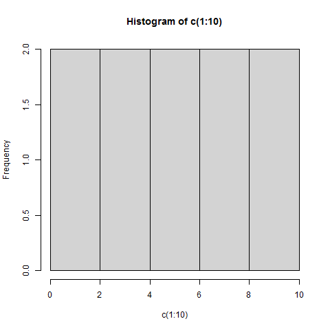

[output not shown]

```
III) Conversão de variáveis
```

III) Conversão de variáveis

[output not shown]

```
a) Do `R` para o `Python`
```

a) Do `R` para o `Python`

```
import pandas as pd
```

[output not shown]

```
%r
```

```
v<-c(1,2,3,4,5)
```

```
write.table(v,file="temporary.txt",quote=FALSE)
```

```
r%
```

```
#f = open("temporary.txt", "r")
```

```
data_v = pd.read_csv('temporary.txt', sep=" ", header=0)
```

```
#f.close()
```

```
#del(f)
```

```
%r
```

```
unlink("temporary.txt")
```

```
# ou: file.remove("temporary.txt")
```

```
r%
```

```
data_v
```

|  | x |
| --- | --- |
| 1 | 1 |
| 2 | 2 |
| 3 | 3 |
| 4 | 4 |
| 5 | 5 |

```
v=data_v.iloc[0:5,0].to_list()
```

```
v
```

```
[1, 2, 3, 4, 5]
```

[output not shown]

```
b) Do `Python` para o `R`
```

b) Do `Python` para o `R`

```
dv = pd.DataFrame({'x': v})
```

```
dv
```

|  | x |
| --- | --- |
| 0 | 1 |
| 1 | 2 |
| 2 | 3 |
| 3 | 4 |
| 4 | 5 |

```
dv.to_csv('data_v.txt', header=True, index=False, sep=" ", mode='w')
```

```
%r
```

```
#v<-c(1,2,3,4,5)
```

```
sink("temporary.txt") # MUDANDO O DESTINO DO OUTPUT
```

```
data_v<-read.table('data_v.txt', header = TRUE, sep=' ')
```

```
# ----------------------- #
```

```
v<-as.matrix(data_v)
```

```
v<-unlist(v[,1])
```

```
# ----------------------- #
```

```
print(v)
```

```
V<-c(1,2,3,4,5)
```

```
print(V)
```

```
sink() # RETORNANDO O DESTINO DO OUTPUT PARA O CONSOLE (terminal)
```

```
unlink("data_v.txt")
```

```
r%
```

```
f = open("temporary.txt", "r")
```

```
print(f.read())
```

```
f.close()
```

```
del(f)
```

```
%r
```

```
unlink("temporary.txt")
```

```
r%
```

```
[1] 1 2 3 4 5
[1] 1 2 3 4 5
```

[output not shown]

```
IV) Executando aplicações interativas a partir do `R`
```

IV) Executando aplicações interativas a partir do `R`

```
%r
```

```
install.packages("shiny")
```

```
r%
```

```
%r
```

```
library(shiny)
```

```
ui <- basicPage(
```

```
  plotOutput("plot1", click = "plot_click"),
```

```
  verbatimTextOutput("info")
```

```
)
```

```
server <- function(input, output, session) {
```

```
  output$plot1 <- renderPlot({
```

```
    plot(mtcars$wt, mtcars$mpg)
```

```
  })
```

```
  output$info <- renderText({
```

```
    paste0("x=", input$plot_click$x, "\ny=", input$plot_click$y)
```

```
  })
```

```
# ---------------------------------------- #
```

```
    session$onSessionEnded({
```

```
        print("Stop!")
```

```
        stopApp
```

```
  })
```

```
# ---------------------------------------- #
```

```
}
```

```
# ------------------------------ #
```

```
print(shinyApp(ui, server))
```

```
# ------------------------------ #
```

```
#ou runApp(list(ui = ui, server = server))
```

```
r%
```

```
import IPython
```

```
IPython.version_info
```

```
(7, 13, 0, '')
```

[output not shown]

```
O programado entre as linhas 18 a 23 da célula acima exemplifica o cuidado em programar o encerramento de uma aplicação para que o programa encerre-a devido ao fechamento da janela pelo usuário.
```

```
Além disso, foi preciso utilizar a função `print` , entre as linhas 27 e 28, para acessar o servidor gerado. Isso tem a ver com a diferença entre o destino do output textual em um console de uma interface própria para o `R` , como o *Rstudio*, e a utilizada aqui, onde os resultados somente são exibidos, no terminal por padrão, somente se for programada a exibição deles, utilizando as funções `print` e `cat` por exemplo. Num console usual, a exibição dos resultados textuais não requer necessariamente o uso dessas funções, pois é suficiente executar o nome de uma variável para que seu valor seja apresentado.
```

O programado entre as linhas 18 a 23 da célula acima exemplifica o cuidado em programar o encerramento de uma aplicação para que o programa encerre-a devido ao fechamento da janela pelo usuário.

Além disso, foi preciso utilizar a função `print` , entre as linhas 27 e 28, para acessar o servidor gerado. Isso tem a ver com a diferença entre o destino do output textual em um console de uma interface própria para o `R` , como o *Rstudio*, e a utilizada aqui, onde os resultados somente são exibidos, no terminal por padrão, somente se for programada a exibição deles, utilizando as funções `print` e `cat` por exemplo. Num console usual, a exibição dos resultados textuais não requer necessariamente o uso dessas funções, pois é suficiente executar o nome de uma variável para que seu valor seja apresentado.

[output not shown]

```
Resultado abaixo:
```

Resultado abaixo:

[output not shown]

```
![](foto6.jpg)
```

[figure not shown]

[output not shown]

```
Isso foi feito utilizando as referências [[2](https://deanattali.com/blog/advanced-shiny-tips/),[3](https://stackoverflow.com/questions/35306295/how-to-stop-running-shiny-app-by-closing-the-browser-window)].
```

Isso foi feito utilizando as referências [[2](https://deanattali.com/blog/advanced-shiny-tips/),[3](https://stackoverflow.com/questions/35306295/how-to-stop-running-shiny-app-by-closing-the-browser-window)].

[output not shown]

```
# Observações:
```

# Observações:

[output not shown]

```
_
```

```
**A)** Tudo isso pode ser utilizado em uma interface IPython notebook online, como o jupyter-notebook online e o colab, evitando transtornos de conflito entre um pacote e o sistema operacional do usuário.
```

```
**B)** No sistema operacional Windows, isso pode ser um pouco mais complicado, pois não há o mesmo suporte para esse pacote que em outros. No entanto, a versão do Anaconda funciona muito bem, embora não seja tão atualizada. A boa notícia é que a versão do Anaconda funciona no `Python` do mecanismo `Pip`. A seguir explico o procedimento necessário para conseguir usar a versão do Anaconda no `Python` do mecanismo `Pip`.
```

_

**A)** Tudo isso pode ser utilizado em uma interface IPython notebook online, como o jupyter-notebook online e o colab, evitando transtornos de conflito entre um pacote e o sistema operacional do usuário.

**B)** No sistema operacional Windows, isso pode ser um pouco mais complicado, pois não há o mesmo suporte para esse pacote que em outros. No entanto, a versão do Anaconda funciona muito bem, embora não seja tão atualizada. A boa notícia é que a versão do Anaconda funciona no `Python` do mecanismo `Pip`. A seguir explico o procedimento necessário para conseguir usar a versão do Anaconda no `Python` do mecanismo `Pip`.

[output not shown]

```
Basta adquirir a pasta do pacote da versão atual do Anaconda, no dia 18/05/2020, 2.9.4, e inserí-la adequadamente num diretório do `Python`. Além disso, é necessário tomar cuidado com as variáveis do sistema operacional.
```

```
Vale a observação de que é necessário ter o `R` instalado no computador para usá-lo por esse pacote.
```

Basta adquirir a pasta do pacote da versão atual do Anaconda, no dia 18/05/2020, 2.9.4, e inserí-la adequadamente num diretório do `Python`. Além disso, é necessário tomar cuidado com as variáveis do sistema operacional.

Vale a observação de que é necessário ter o `R` instalado no computador para usá-lo por esse pacote.

[output not shown]

```
I) Tomou-se o cuidado de instalar o `R` em um diretório no Windows (C:), em vez de em arquivos de programas ou similares internos a Windos (C:), para evitar problemas com permissão de administrador. No meu caso, escolhi :
```

I) Tomou-se o cuidado de instalar o `R` em um diretório no Windows (C:), em vez de em arquivos de programas ou similares internos a Windos (C:), para evitar problemas com permissão de administrador. No meu caso, escolhi :

[output not shown]

```
![](foto13.jpg)
```

[figure not shown]

[output not shown]

```
II) Analogamente, instalou-se o `Rtools` *compatível* com a versão do `R` instalada.
```

II) Analogamente, instalou-se o `Rtools` *compatível* com a versão do `R` instalada.

[output not shown]

```
![](foto14.jpg)
```

[figure not shown]

[output not shown]

```
Também, foi preciso configurar variáveis do sistema `R_HOME`, `R_LIBS`, `R_USER` e a variável de usuário `Path`.
```

Também, foi preciso configurar variáveis do sistema `R_HOME`, `R_LIBS`, `R_USER` e a variável de usuário `Path`.

[output not shown]

```
![](foto15.jpg)
```

[figure not shown]

[output not shown]

```
Então,
```

Então,

[output not shown]

```
![](foto19.jpg)
```

[figure not shown]

[output not shown]

```
Depois,
```

Depois,

[output not shown]

```
![](foto16.jpg)
```

[figure not shown]

[output not shown]

```
Após isso, Registrou-se os seguintes endereços como `R_HOME` e `R_LIBS`.
```

Após isso, Registrou-se os seguintes endereços como `R_HOME` e `R_LIBS`.

[output not shown]

```
![](foto17.jpg)
```

[figure not shown]

[output not shown]

```
Logo em seguida, registrou-se o diretório do `Python` que **deve hospedar o pacote** normalmente. Percebe-se a sequência \Lib\site-packages\
```

Logo em seguida, registrou-se o diretório do `Python` que **deve hospedar o pacote** normalmente. Percebe-se a sequência \Lib\site-packages\

[output not shown]

```
![](foto18.jpg)
```

```
Acima, anotou-se o endereço do `rpy2` no `Python` vinculado ao *pip* como `R_USER` .
```

[figure not shown]

Acima, anotou-se o endereço do `rpy2` no `Python` vinculado ao *pip* como `R_USER` .

[output not shown]

```
Daí,
```

Daí,

[output not shown]

```
![](foto20.jpg)
```

[figure not shown]

[output not shown]

```
Depois disso, acrescentou-se o endereço `bin` do `R` à variável Path.
```

Depois disso, acrescentou-se o endereço `bin` do `R` à variável Path.

[output not shown]

```
![](foto21.jpg)
```

[figure not shown]

[output not shown]

```
Acrescentou-se o diretório da pasta `bin` interna ao diretório onde foi instalado o `R` à variável de usuário `Path`.
```

Acrescentou-se o diretório da pasta `bin` interna ao diretório onde foi instalado o `R` à variável de usuário `Path`.

[output not shown]

```
# Referências
```

# Referências

[output not shown]

```
_
```

```
[1] (https://rpy2.github.io/doc/v2.9.x/html/rinterface.html)
```

```
Acesso em 24 de abil de 2020.
```

```
[2] https://deanattali.com/blog/advanced-shiny-tips/
```

```
Acesso em 24 de abil de 2020.
```

```
[3] https://stackoverflow.com/questions/35306295/how-to-stop-running-shiny-app-by-closing-the-browser-window
```

```
Acesso em 24 de abil de 2020.
```

_

[1] (https://rpy2.github.io/doc/v2.9.x/html/rinterface.html)

Acesso em 24 de abil de 2020.

[2] https://deanattali.com/blog/advanced-shiny-tips/

Acesso em 24 de abil de 2020.

[3] https://stackoverflow.com/questions/35306295/how-to-stop-running-shiny-app-by-closing-the-browser-window

Acesso em 24 de abil de 2020.